# Bayesian Inference - Introduction with Applications

Felipe Angelim

## About me

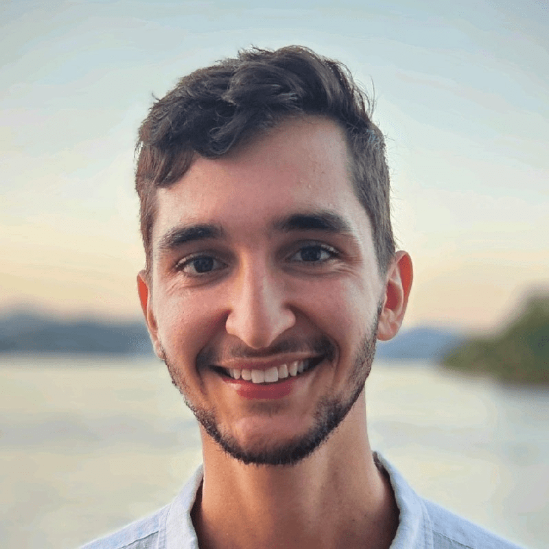

Felipe Angelim

Tech Lead @ Mercado Libre

Core Dev @ Sktime

Creator/Dev @ Prophetverse

felipeangelim.com

## Agenda

1. Motivation
2. Bayes: Priors, posteriors, and likelihoods
3. Bayesian Inference applications

# Motivation

## Motivation

[figure not shown]

## Motivation

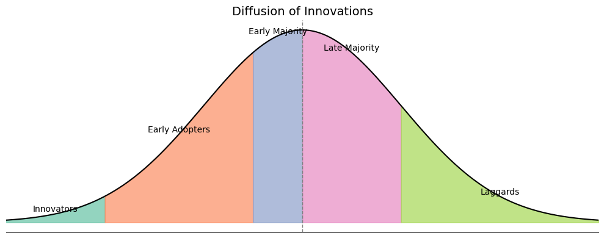

- **Scalar number is not enough**: we want to quantify uncertainty.
- **Small data requires regularization**: with bayesian methods, we use priors and domain knowledge.

# Priors, Posteriors, and Likelihoods

## Key ingredients

### Priors, Posteriors, and Likelihoods

$$\underbrace{P(\theta|X)}_{\text{Posterior}} = \frac{\overbrace{P(X|\theta)}^{\text{Likelihood}} \; \overbrace{P(\theta)}^{\text{Prior}}}{\underbrace{P(X)}_{\text{Evidence}}} \implies \quad \quad P(\theta|X) {\LARGE \propto} P(X|\theta) P(\theta)$$

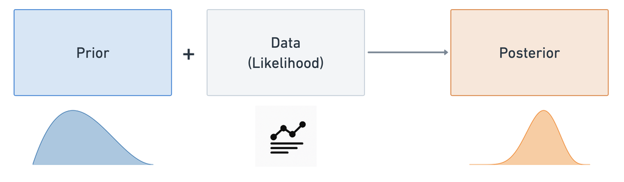

## Inference

- We only now how to compute $f_X(\theta) = P(X|\theta)P(\theta)$, that is proportional to the posterior.
- Inference methods:
  1. **Sampling methods**: e.g., Markov Chain Monte Carlo (MCMC).
  2. **Variational inference**: approximate the posterior with a simpler distribution.
  3. **Maximum a Posteriori (MAP)**: find the mode of the posterior distribution.

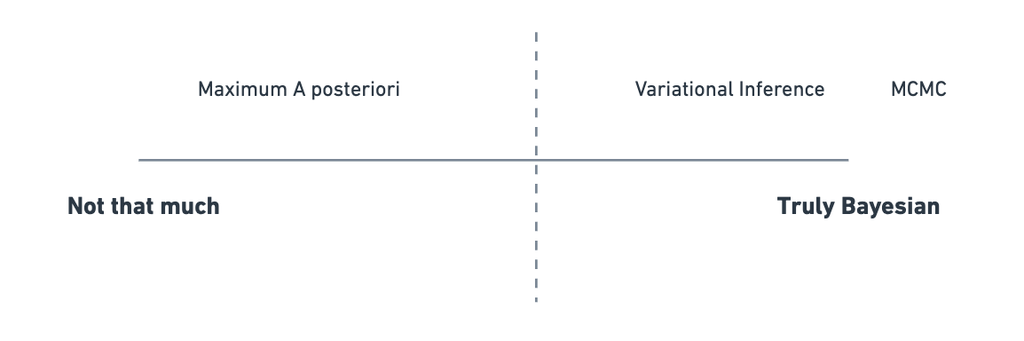

## Inference

### Markov Chain Monte Carlo (MCMC)

- Markov Chains: sequence of random events/states, with transition probabilities between them.
- Can have stationary distributions, “equilibrium”.
- Idea: build a chain whose “equilibrium” is the posterior distribution of interest.
- Here Monte Carlo is used to be able to sample from such target distribution.

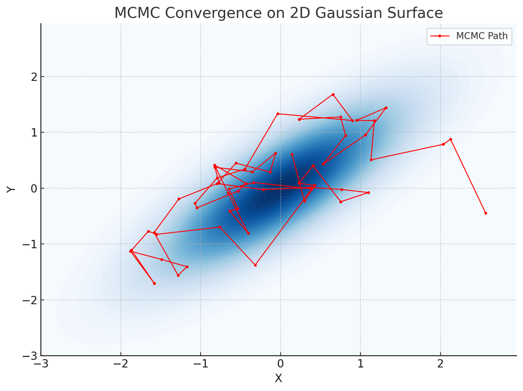

## Inference

### Markov Chain Monte Carlo (MCMC)

[figure not shown]

## Simple linear regression

$$\alpha \sim N(0, 10) \\
\beta \sim N(0, 10) \\
\sigma \sim \text{HalfCauchy}(5) \\
Y_i \sim N(\alpha + \beta X_i, \sigma)$$

```python
import numpyro
from numpyro import distributions as dist

def linear_regression_model(x, y=None):

    # Priors on intercept and slope
    alpha = numpyro.sample("alpha", dist.Normal(0.0, 10.0))
    beta = numpyro.sample("beta", dist.Normal(0.0, 10.0))

    # Prior on noise scale (sigma > 0)
    sigma = numpyro.sample("sigma", dist.HalfCauchy(5.0))

    # Likelihood
    mean = alpha + beta * x
    with numpyro.plate("data", x.shape[0]):
        numpyro.sample("obs", dist.Normal(mean, sigma), obs=y)
```

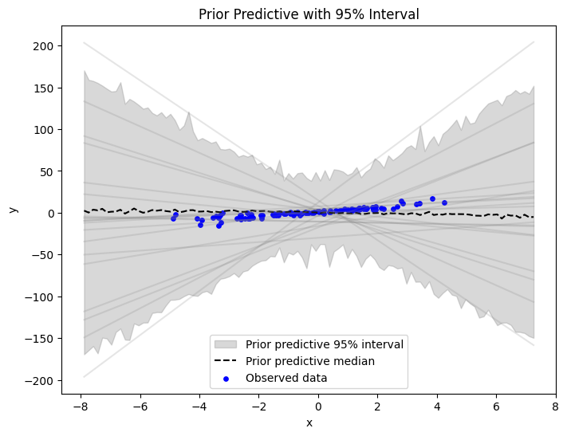

## Simple linear regression

```python
from numpyro.infer import MCMC, NUTS
import jax.random as random

# Random key for reproducibility
rng_key = random.PRNGKey(0)

kernel = NUTS(linear_regression_model)
mcmc = MCMC(kernel, num_warmup=1000, num_samples=2000)
mcmc.run(rng_key, x_data, y_data)
posterior_samples = mcmc.get_samples()
```

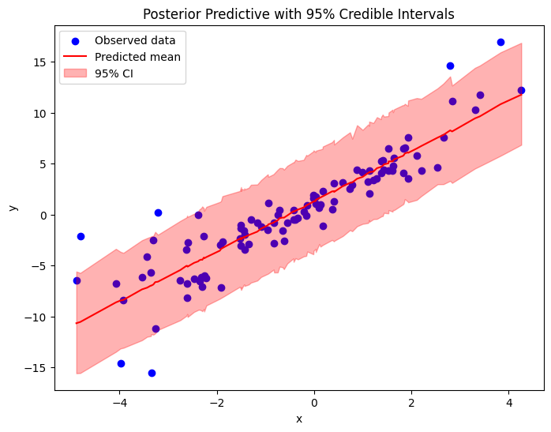

## Bayesian Neural Networks

- Extend this idea of “random” parameters to neural networks’ weights.
- Use priors on weights, and sample from the posterior distribution.
- $weights \sim N(0, I)$, for example

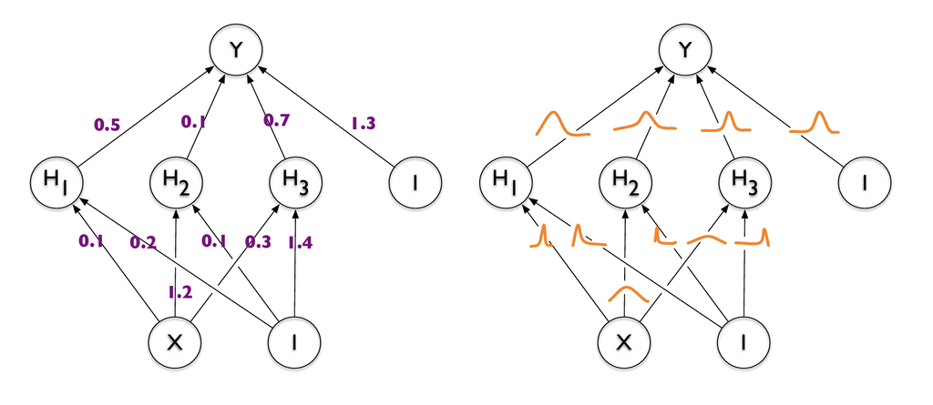

Blundell, Charles, et al. “Weight uncertainty in neural network.” International conference on machine learning. PMLR, 2015.

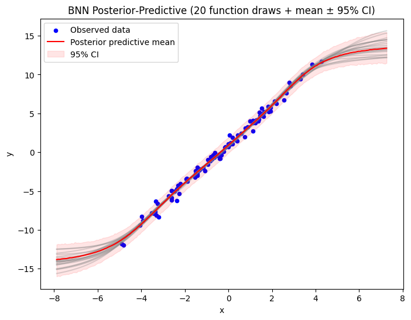

## Inference

### Variational Inference

- We can also accept that the true posterior may be really hard to compute, and approximate it with a simpler distribution.
- Search $q \in Q$ that minimizes the Kullback-Leibler divergence $D_{KL}(q || p(\cdot | X))$ w.r.t the true posterior.
- Variational inference (VI) provides a fast and approximate solution to the problem.
- Nowadays, libraries provide automatic Stochastic Variational Inference (SVI).
- Usually the choice for Bayesian Neural Networks and large datasets.

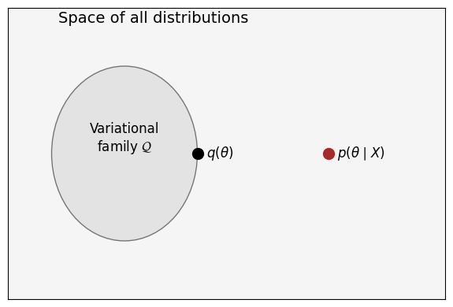

## Inference

### Maximum A Posteriori (MAP)

- Find the mode (maximum) of the posterior distribution.
- Not a full Bayesian inference, but can be useful for fast inference and regularization.

$$\arg\max_\theta P(\theta | X)$$

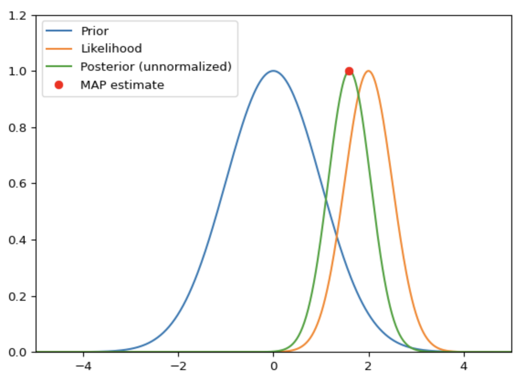

## Inference

### Maximum A Posteriori (MAP)

- **You are already using bayes!**
- Ridge regression, and Lasso, can be obtained from a Bayesian perspective!
- Bayesian inference offer a more interpretable vision over regularization.

Ridge regression:

$$Y|X = X\beta + \epsilon, \quad \epsilon \sim N(0, \sigma^2 I) \\
\hat{\beta} = \arg\min_\beta \left\{ ||y - X\beta||^2 + \lambda ||\beta||^2 \right\}$$

Bayesian Ridge regression:

$$Y | X \sim N(X\beta, \sigma^2 I) \\
\beta \sim N(0, \frac{I}{\tau^2}) \\
\hat{\beta} = \arg\max_\beta P(\beta | X, Y)$$

## You are already using bayes

$$P(\beta)$$

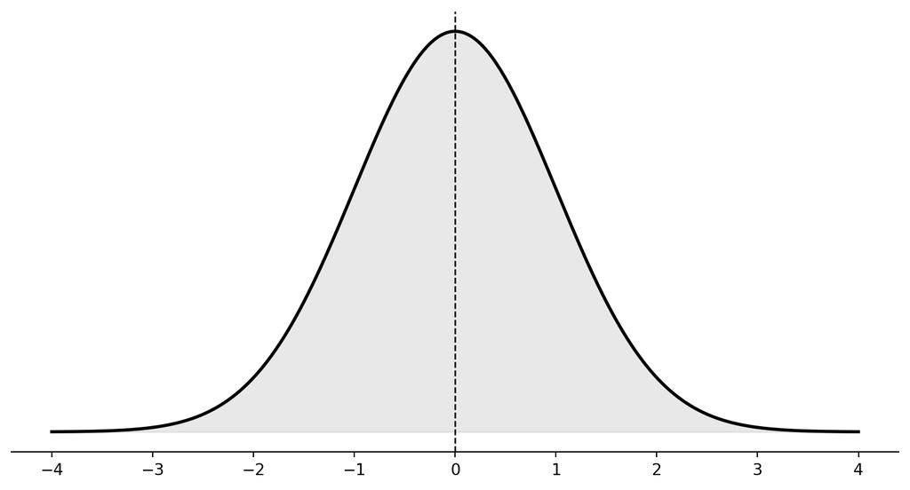

# Applications on timeseries

## Total Addressable market (TAM) estimation

- **Problem**: Estimate the total number of potential users/customers in a market.
- **Approach**: Use a Bayesian model to estimate the growth of users over time, incorporating prior knowledge about market saturation.

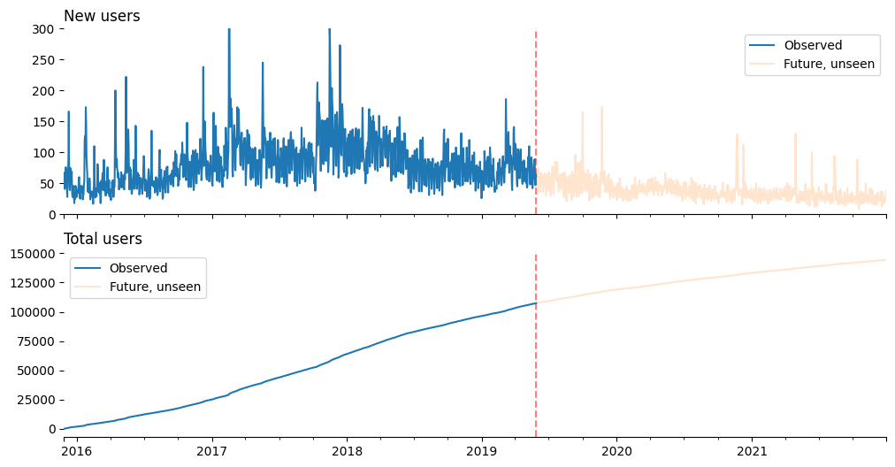

$$G(t) = \frac{C_1(t-t_0) + C_2}{\left(1 + \exp(-\alpha v (t - t_0))\right)^{\frac{1}{v}}}$$

$$C_2 \in \mathbb{R}_+ = \text{is the constant capacity term}\\
C_1 \in \mathbb{R}_+ = \text{is the linear increasing rate of the capacity}\\
t_0 \in \mathbb{R} = \text{is the time offset term}\\
v \in \mathbb{R}_+ = \text{determines the shape of the curve} \\
\alpha \in \mathbb{R} = \text{is the rate}$$

See more in [custom trend tutorial in prophetverse](https://prophetverse.com/latest/howto/custom_trend.html)

### Total Addressable market (TAM) estimation

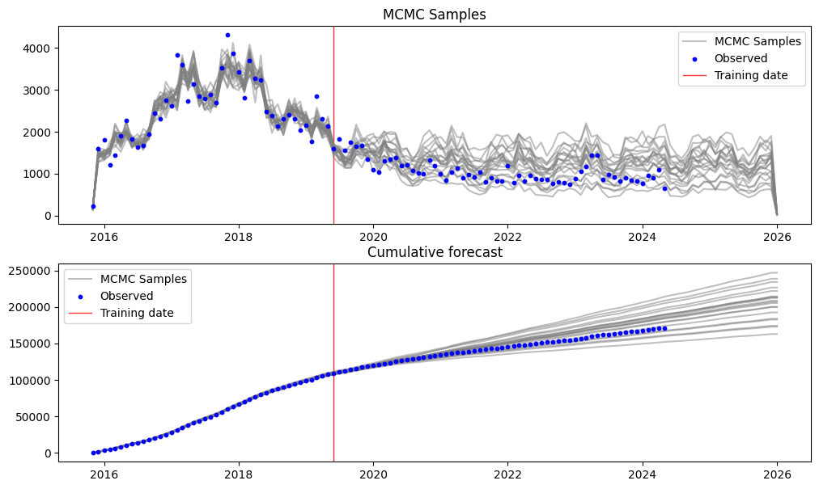

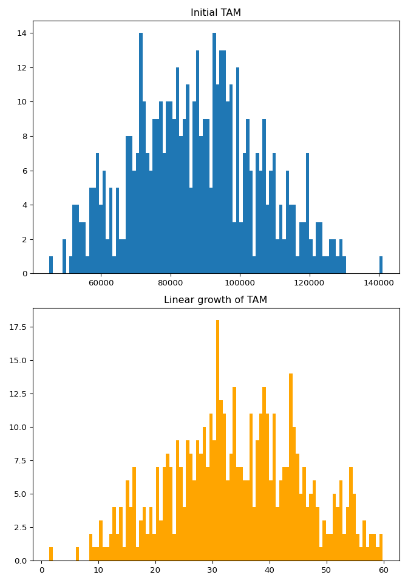

See more in [custom trend tutorial in prophetverse](https://prophetverse.com/latest/howto/custom_trend.html)

## Marketing Mix Modeling

- **Problem**: Estimate the impact of different marketing channels on sales.
- **Approach**: Use Bayesian models to:
  - Incorporate prior knowledge about the effectiveness of each channel.
  - Estimate the posterior distribution of the impact of each channel on sales.
  - Incorporate A/B testing results to refine estimates.

$$E[\text{Sales} | \text{Marketing Channels}] = \text{trend} + \text{seasonality} + f_{\text{social_media}}(x_{\text{social_media}}) + f_{\text{email}}(x_{\text{email}}) + f_{\text{tv}}(x_{\text{tv}})$$

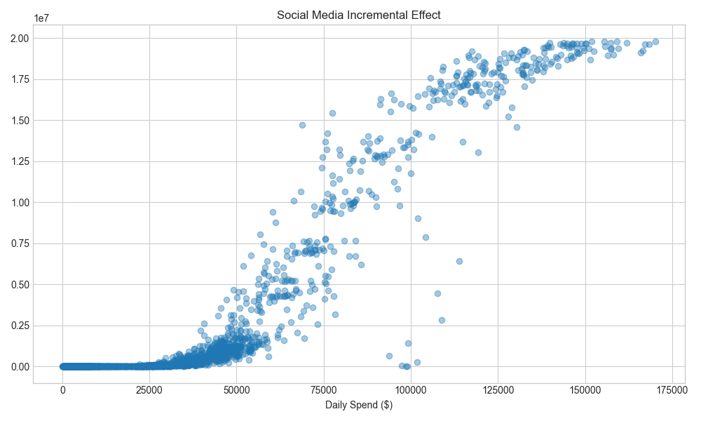

## Other applications

- **Forecasting for Inventory Management:** Estimating the probability of stock-outs and optimal reorder points.
- **Censored Data Analysis:** (e.g., survival analysis in medicine, reliability engineering)
- **A/B Testing:** Quantifying $P(\text{Variant A > Variant B})$ and the magnitude of difference.
- **Hierarchical Models:** Sharing information between groups (e.g., price elasticity across different products/regions, user behavior in different cohorts).

## Conclusion

- Acts as regularization
- Inference comes in many flavors: MCMC, Variational Inference, MAP.
- Probabilistic Programming Languages (PPLs) make it easy to implement complex models.
- Provide rich uncertainty quantification.
- Natural way to incorporate domain knowledge through priors.

[figure not shown]

[figure not shown]

[figure not shown]

## Thank you!

- Join sktime and Prophetverse’s discord channel!

# Extras

## Motivation: Why Bayesian?

**Which of these is a Bayesian statement, and which is Frequentist**?

**A.** There is a 95% probability that the **true value $\theta$ lies in my interval $[A, B]$**.

**B.** There is 95% chance that **my interval $[A, B]$ contains the true quantity $\theta$**.

*If $[A, B]$ is an interval generated by a model, and $\theta$ is the parameter of interest.*

## Motivation: Interpreting Intervals

**Answer:**

> **A. (Bayesian): “There is a 95% probability that the true quantity $\theta$ lies in $[A, B]$”** * Treats $\theta$ as random, data as fixed. Probability statement about the parameter.

> **B. (Frequentist): “There is 95% chance that $[A, B]$ contains the true quantity $\theta$”** * Treats $\theta$ as fixed, data (and thus interval) as random. Statement about the procedure: if repeated many times, 95% of such intervals would capture the true $\theta$.

The key difference: Bayesian credible intervals condition on the observed data. Frequentist confidence intervals consider the randomness of the data generation process.

## Visualizing the Difference

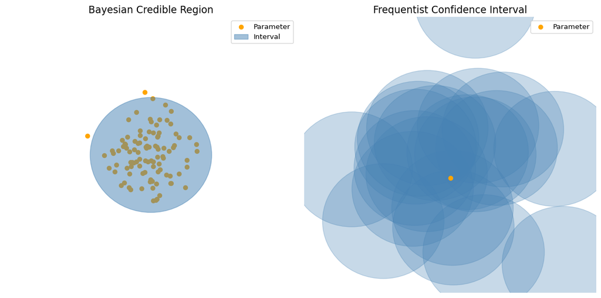

Adapted from Jake VanderPlas. ([Link to video](http://www.youtube.com/watch?v=KhAUfqhLakw)).

## Motivation

### Principled Regularization

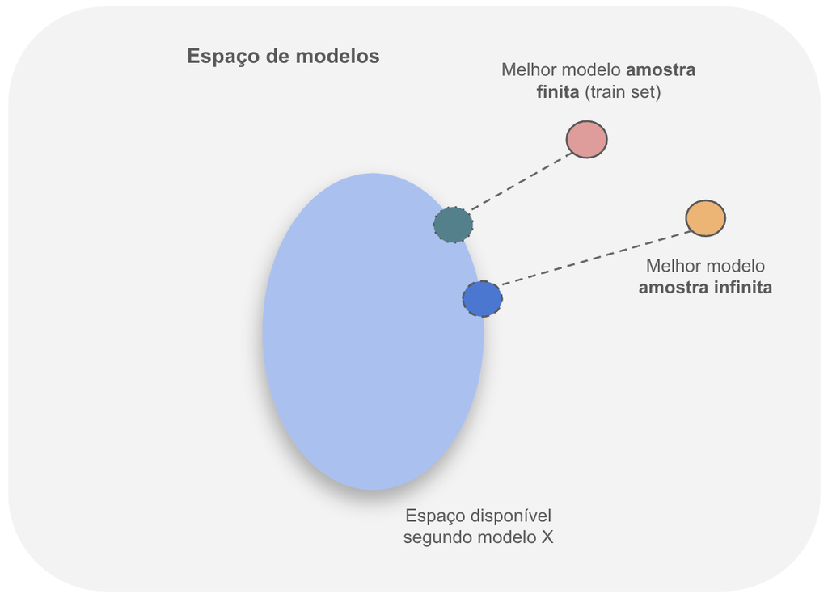

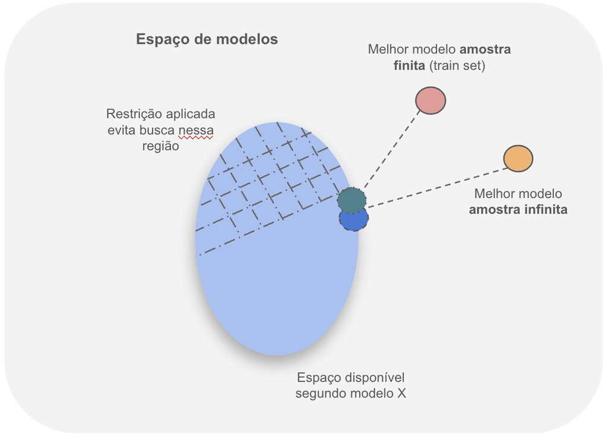

- Priors act as a natural way to regularize models and prevent overfitting.
- For example, Lasso and Ridge regressions are “bayesian”.